# Hoosier CrossFit Gym

Project Team 3: Eungkoo (Eugene) Kahng, Syaza Senin, Jackson Taylor, Miriam Hu

April 20, 2017

# Analysis of Attendance Trends

## Introduction

In this project, we will continue the analysis of Shaun Tieman’s Hoosier CrossFit gym attendance data in order to help him make certain business decisions as he prepares to open a second location. For the final report, our group decided to focus on the attendance rate and trends of Shaun’s CrossFit classes.

Among the five research questions provided, we find it more helpful and useful to scrutinize the meaningful trends of attendance rather than just the analysis of class popularity. If we can help Shaun discover the trends of attendance, we believe he will be able to organize his programs and contents of classes accordingly for all seasons, months, and days of a year. For example, if there is a certain day that is attended most often, Shaun will want to schedule more classes and instructors for that day of the week. If there is perhaps a month that is least-attended, Shaun may want to cut back on hours then in order not to waste time.

In other words, no matter which classes are most favored by the members of the gym, our report of how time affects the attendance should be his top priority before deciding the class contents for his new future gym. From that point, he can organize all his class programs well, since almost all CrossFit classes are being run inside a gym.

One research question we want to answer is whether all four seasons of a year affect attendance differently. Seasonal impacts on attendance should be a huge concern for Shaun to best run the gym. Depending on the seasons, he might be able to control the use of his programs and decide to add or cut back required instructors, membership options, and classes. By doing so, he will be in great shape to control financially related decisions and expenses for management. Just from intuition, we believe summer and winter are the seasons when relatively fewer people would take classes compared to spring and fall. Since major breaks take places during summer and winter, there is a high chance that student members will be out of town during the periods, we should expect fewer people showing up for class. Also, other events such as the Olympics and extreme (cold or stormy) weather might play a role in affecting individuals’ attendance; people may feel inspired to work out during and just after the Olympics occur, and they may be disinclined to attend class when the weather makes it inconvenient to get there.

Our next research hypothesis is that weekdays and weekends will have different attendances. We are not so sure which day will be more preferred by members. This is because there might be a chance that the members will be more likely to take classes on weekends compared to weekdays due to their use of extra leisure time. On the other hand, there might be chance that weekday classes are more preferred due to convenience of time management. For example, you can directly go to gym after you are done with school or work before getting home. Likewise, this is hard to predict which day (week vs. weekend) is more favored. Thus, finding out and analyzing the trend of a whole week’s attendance will be very helpful for him to manage and run his programs for the future.

## Exploratory Data Results & Analysis

We chose to include CrossFit Classes, Block Classes, Competitor WOD, CrossFit Kids, CrossFit Light, Endurance, Free Community Class, Mobility Class, Olympic Lifting, On Ramp, and Yoga as the classes to analyze. These seem to be the real classes that Hoosier CrossFit has to offer, so we removed the various events and t-shirt data.

### Attendance of Each Month

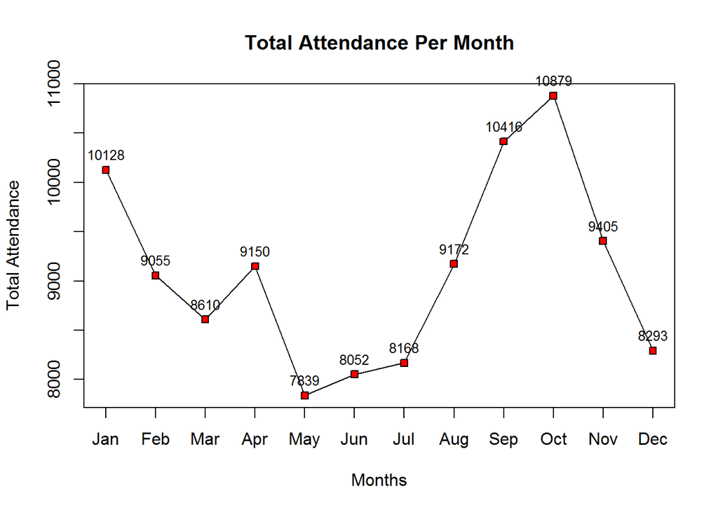

Total Show Up Per Month

We combined all the data from 2011 to 2017 and viewed the months as a whole. As we can see from the plot *Total Attendance Per Months*, in the range of seven years, the most attended month was in October, when 10879 people attended class. May had the lowest attendance at 7839 people, followed by June with 8052 and July, with 8168. We can hypothesize that during the time of long summer break, most members who are not from Blooomington go back to their hometown. The attendance for March and December is also relatively low, which we can assume is because of the spring and winter break.

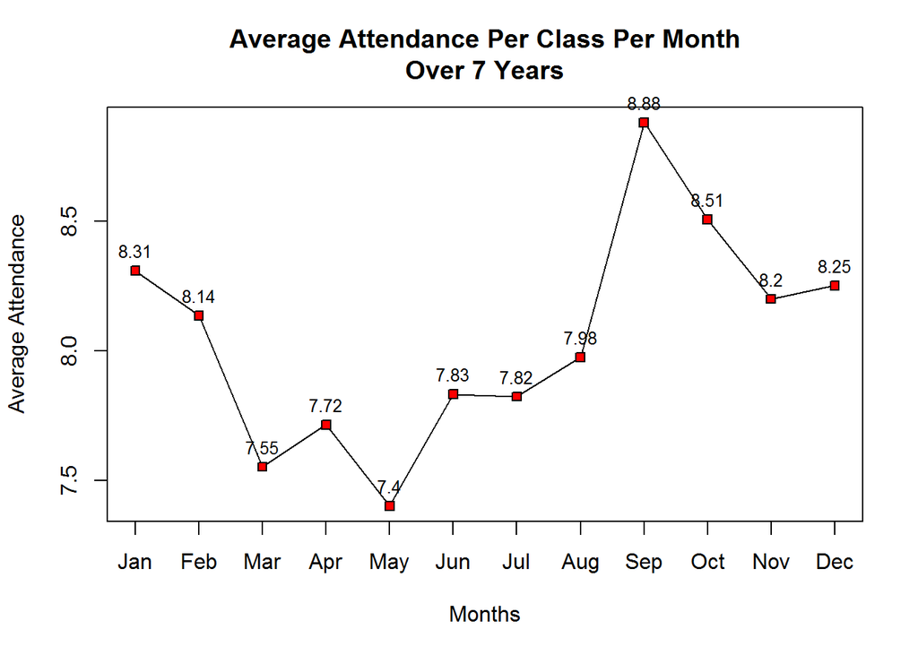

Total Show Up Per Month Divided by Total Classes Offered

This graph is displaying a deeper analysis by standardizing total attendance by total classes offered throughout the seven-year period. We divided the total attendance by total classes offered because we wanted to see the average occupancy of attendance by members per each month. In other words, we are able to see how each month’s attendance is distributed based on the number of classes offered. For example, December’s raw attendance is low, but there may have been fewer classes offered that month. October’s raw attendance is high, but if there were significantly more classes offered that month, October’s attendance rates may be lower than they appear.

|  | Months | Total Attendance | Average Attendance Per Class Per Month |
| --- | --- | --- | --- |
| 01 | Jan | 10128 | 8.31 |
| 02 | Feb | 9055 | 8.14 |
| 03 | Mar | 8610 | 7.55 |
| 04 | Apr | 9150 | 7.72 |
| 05 | May | 7839 | 7.4 |
| 06 | Jun | 8052 | 7.83 |
| 07 | Jul | 8168 | 7.82 |
| 08 | Aug | 9172 | 7.98 |
| 09 | Sep | 10416 | 8.88 |
| 10 | Oct | 10879 | 8.51 |
| 11 | Nov | 9405 | 8.2 |
| 12 | Dec | 8293 | 8.25 |

This is the table including the total attendance per months and the standardized values of attendance per month based on total classes offered.

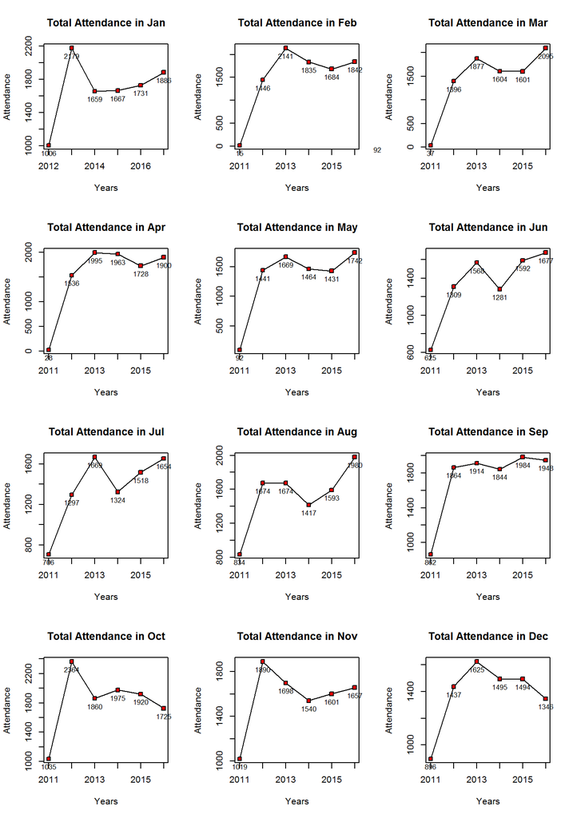

Total Attendance Per Month From 2011-2017

### Trends in attendance throughout the year

| Years | Average Percentage of Attendance |
| --- | --- |
| 2011 | 78.37 |
| 2012 | 99.82 |
| 2013 | 95.36 |
| 2014 | 99.54 |
| 2015 | 99.90 |
| 2016 | 99.78 |
| 2017 | 100.00 |

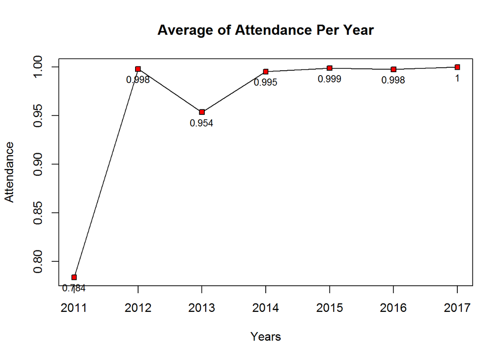

Average Attendance Per Year

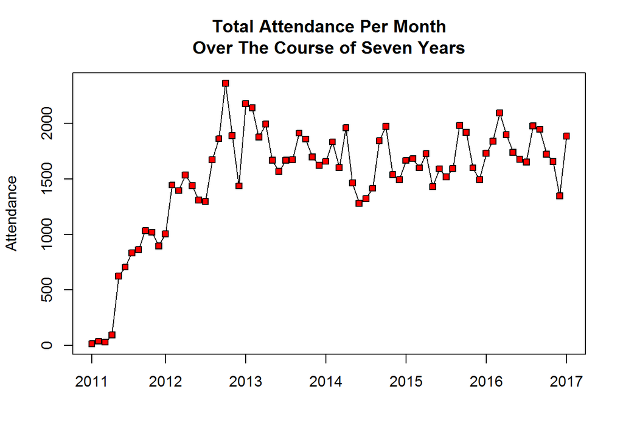

Total Attendance In 2011-2017

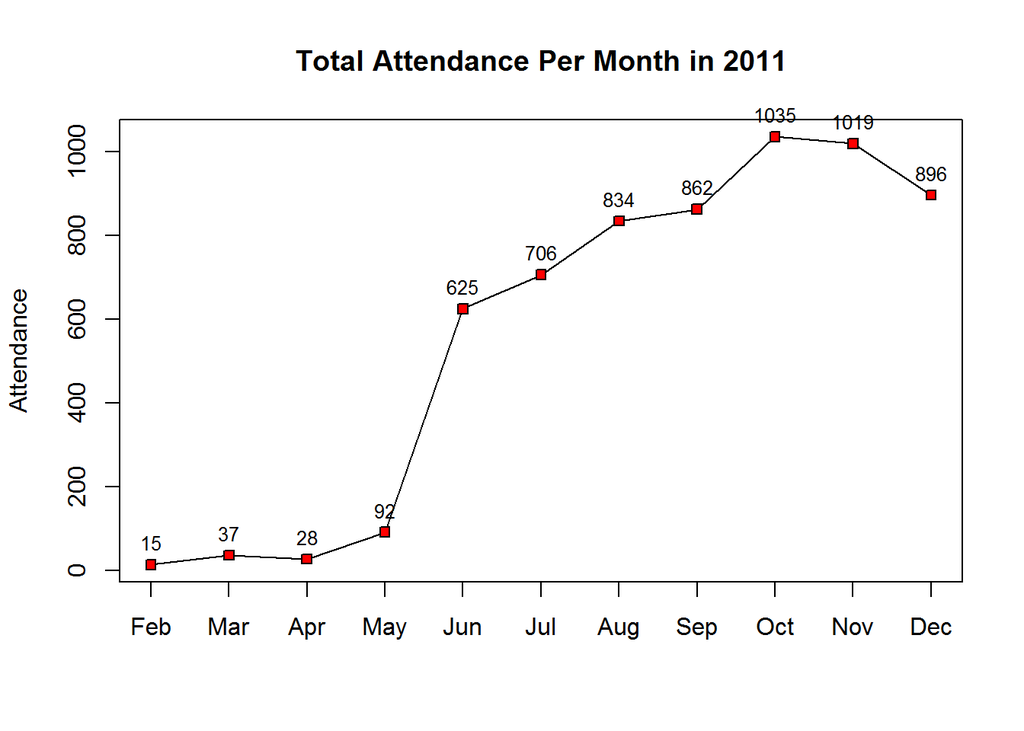

Total Attendance In 2011-2017

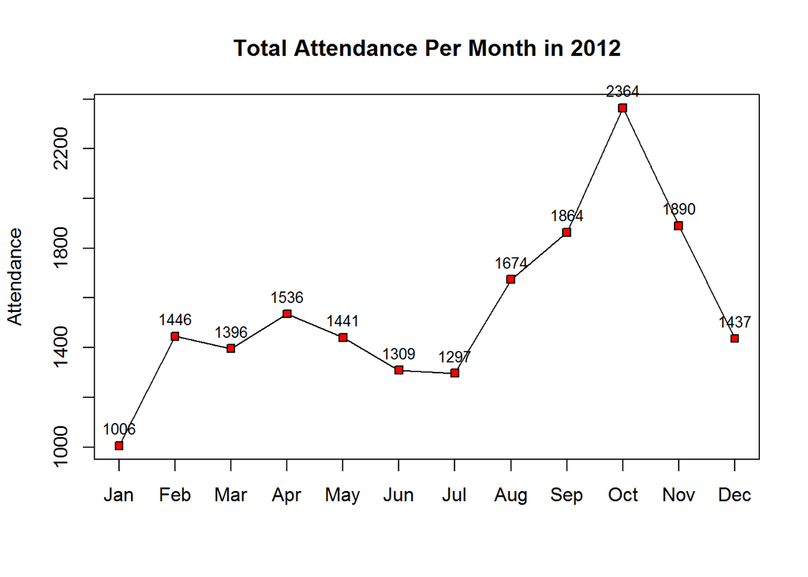

Total Attendance In 2011-2017

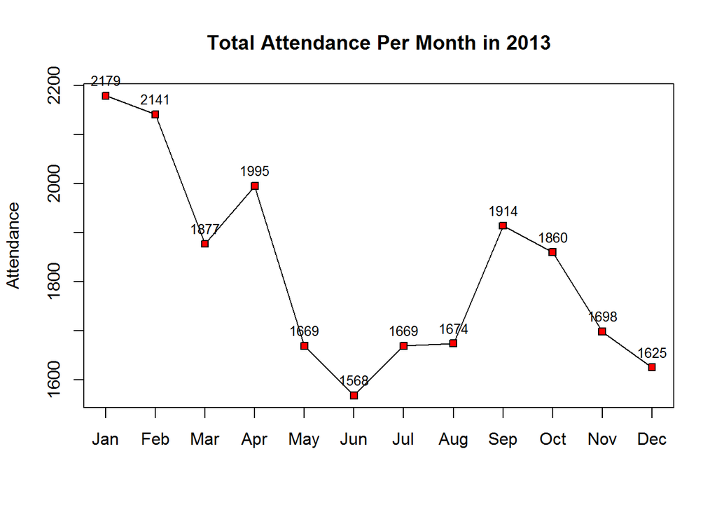

Total Attendance In 2011-2017

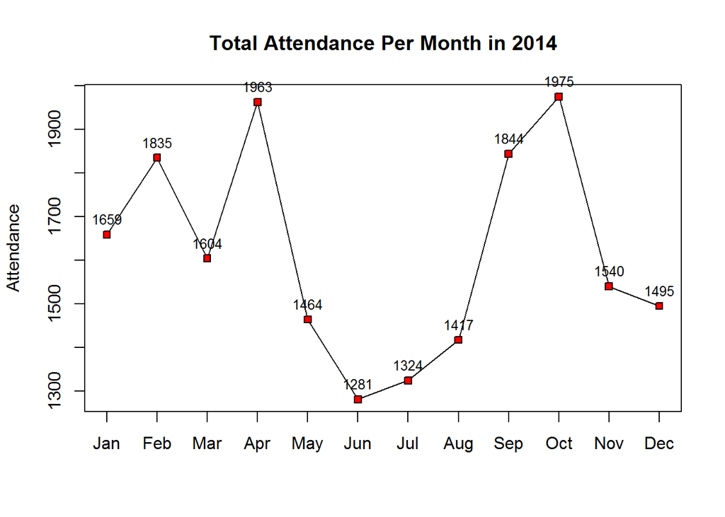

Total Attendance In 2011-2017

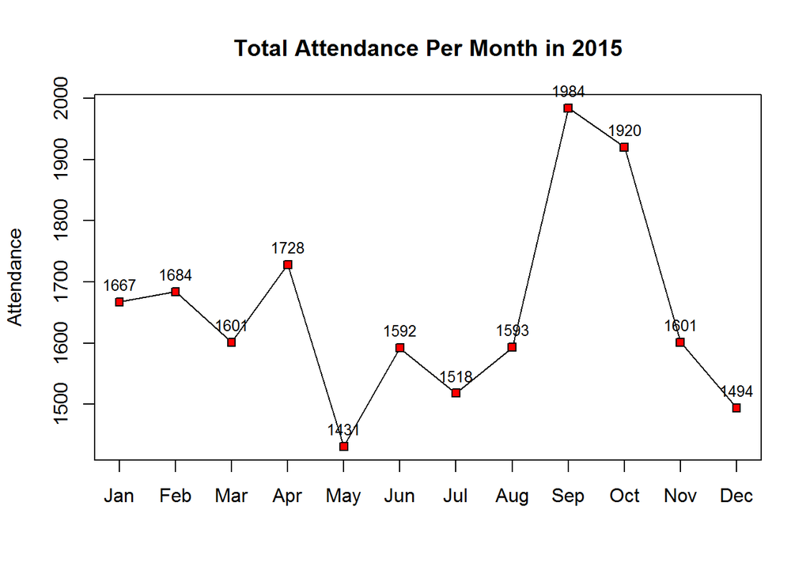

Total Attendance In 2011-2017

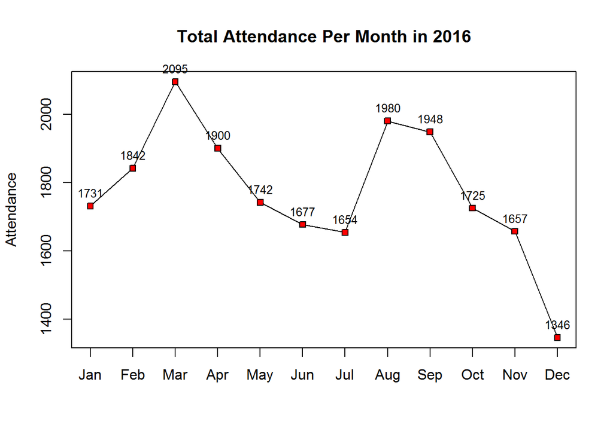

Total Attendance In 2011-2017

We can break this question into two aspects. We can first just find attendance trends for the seven-year term from 2011 to 2017. We can also scrutinize the trends of each month’s attendence rate throughout the whole seven-year term. As you can see from the first plot, the attendance between 2011 and 2012 soared, and this is probably because the members were more likely to stick to their work-out routine as most of them decided to start their programs. In addition, the members back then were also likely to bring in others such as their families or friends, since Hoosier CrossFit was relatively new at this point and would have filled a niche for CrossFit enthusiasts in Bloomington.

The year between 2012 and 2013 displays a little bit of drop in attendance. We might attribute this fall to some drop in marketing, although we cannot know for sure without additional information from Shaun. After 2013, the attendance rate has increased slightly but steadily.

Next, comparing each years’ monthly attendance rates, our group found one trend interesting: Except in 2011, attendance rate tends to plunge from late spring until summer and soar back after summer peaking around September and October. We believe this trend occurs when people start working out as summer break ends and semester begins and we know people tend to pursue healthy behaviors as they resume their work or school after the long break. Attendance dips slightly in November and December, which may be due to Thanksgiving and winter break.

### Attendance Trend On Days

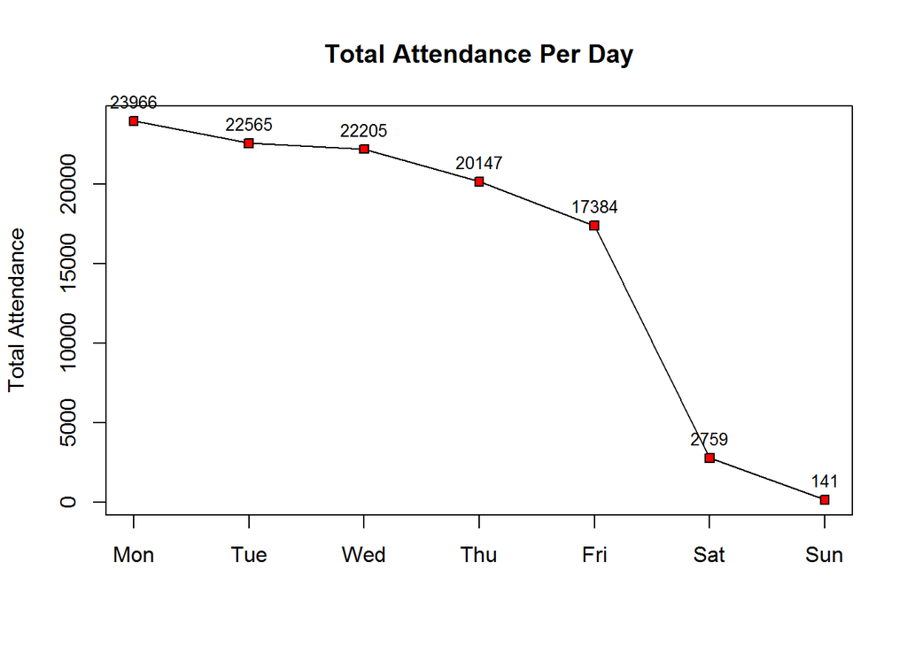

Total Show Up

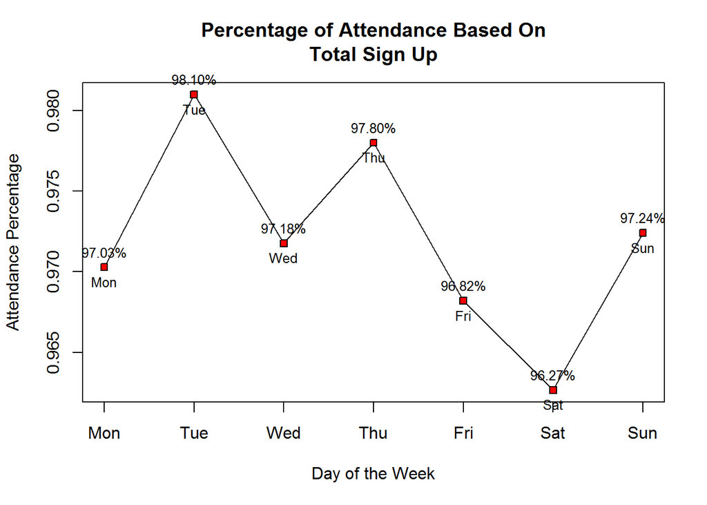

Percentage of Total Show Up Divided by Total Sign Up

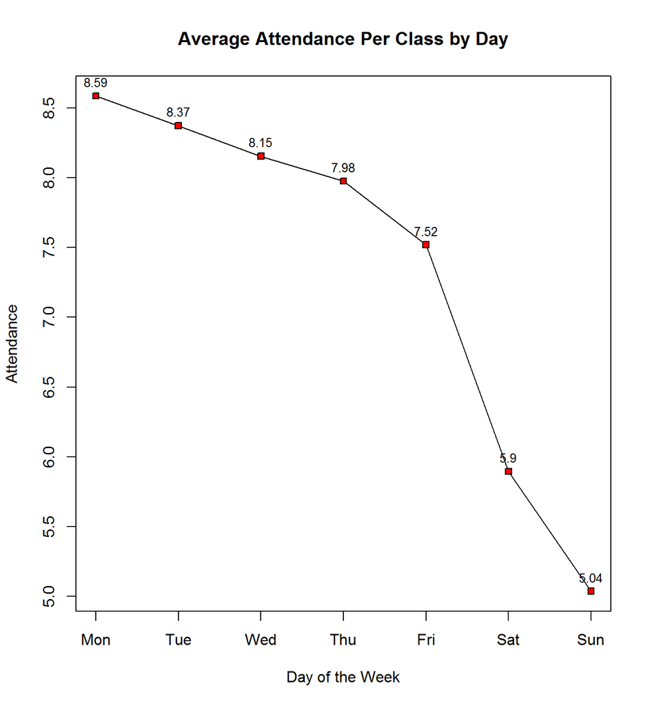

Total Show Up Divided by Total Classes Offered Per Day

Firstly, we can see that Monday is the most popular day for the gym, and there are fewer gym-goers as the week progresses. Saturday and Sunday have very small raw attendance numbers, but this is because there are fewer classes offered on weekends (one to three on Saturdays and usually none on Sundays). Thus, we should re-scale the data to see which days are popular relative to the number of classes scheduled, just as we did with the months.

The second plot shows the total attendance for each day divided by the number of people who signed up, giving the percent attendance. It is clear that most people who sign up for the class also show up. Here you can find an interesting change from the first graph of raw attendance by day. Sunday has a higher percent attendance than Saturday; that is, people who sign up for a Sunday class will tend to go to class more than for Saturday classes.

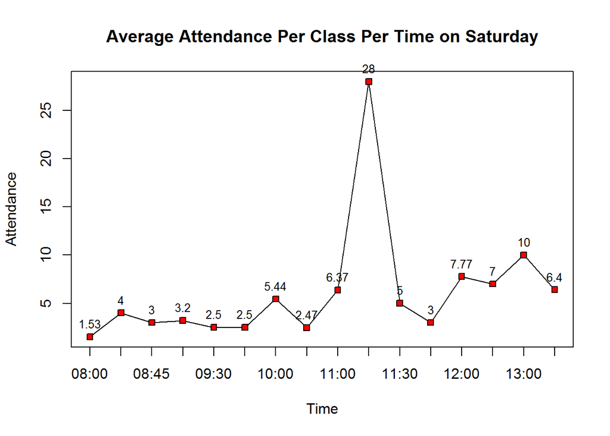

We thought that it was odd that Saturday had a lower average attendance per class; it would make sense that people have more free time on the weekend. So we examined a similar breakdown as before just for Saturdays. We found average class attendance to be highest at 11:00 a.m., 11:15 a.m., 12:00 p.m., and 1:00 p.m. However, we should disregard 11:15 p.m. and 1:00 p.m.; too few classes were offered at those times to draw reasonable conclusions. Therefore, we can see that average class attendance for Saturdays is higher at noon than 11:00 a.m. It seems plausable that moving the class time from the current schedule at 11:00 a.m. to noon would boost attendance. Of course, this change appears to be rather minimal: on average, 1.4 extra people per Saturday.

## Discussions/Results

For the total attendance per month for each year, except for the year 2011, we see the same trends: high spring and fall, low summer and December)

For the total attendance per day, which might help us to reject/not reject our second hypothesis, *attendance during weekdays against weekend*, a very clear attendance tendency is observed. Attendance peaks in Monday through Wedensday and decreases all the way down to Sunday. While Monday through Friday occupies about 97 percent of total attendance, only the remaining 3 percent is the attendence rate for weekends throughout the seven-year term. However, this approach might not be helpful at all in a sense that we never know about the popularity of certain days in a week if we only consider the number of signups and no other information.

The most crucial thing to consider is how the classes have been offered differently for week days and weekends in terms of class limitations such as total amount of seats and time. We found it very meaningful to compare the attendance rate per day (based on total classes offered per day) and attendance rate per day (based on total sign up of those classes). We found that there is a jump from Saturday to Sunday for the percentage attendance (number of attendances divided by number of signups), suggesting that more people show up to the Sunday classes that they signed up for than for Saturday.

However, even after we controlled for the number of classes offered, the trend we saw earlier continued: Monday attendance is highest and declines with each subsequent day.